# Computer Science 1

## Problem 4

> In this section, you will learn how to explor numerical data split by categorical data.

The problem also uses data from gapminder, which tracks demographics in countries around the world over time. For this proble, we will focus on how the lif e expectancy differs from continent to continent. This requires that you conduct your analysis at continent level.

1. Open `gapminder.omv` dataset from Problem 3 in *jamovi*.
2. Filter out the dataset that contains only 2007 data.

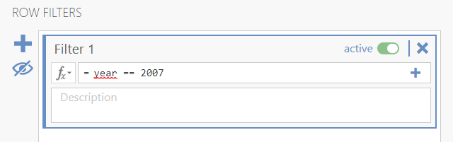

Filtering dataset for 2007 data

3. Calculate the mean and median life expectancy for each continent.

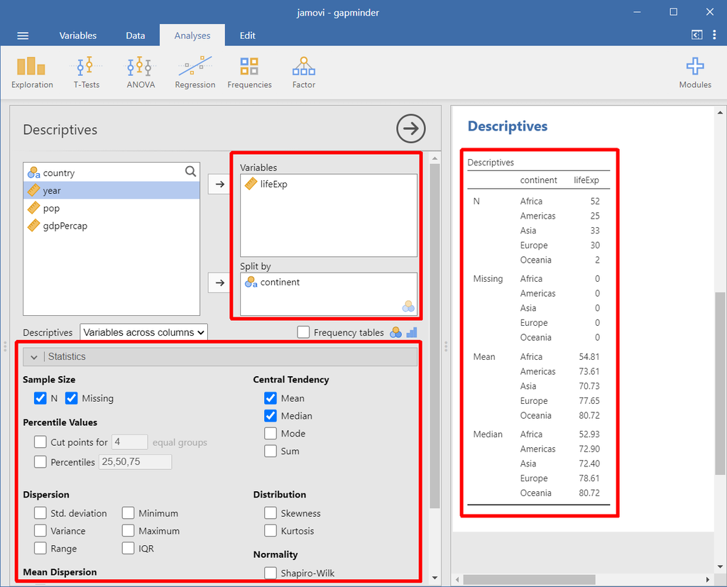

`lifeExp` split by `continent`

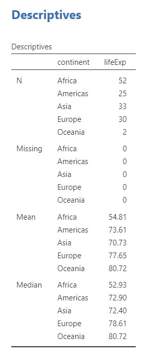

Descriptive statistics for `lifeExp` split by `continent`

4. If you’re unsure whether you’re working with symmetric or skewed distributions, it’s a good idea to consider a robust measure like IQR in addition to the usual measures of variance or standard deviation. For each continent, summarize life expectancies using standard deviation and IQR.

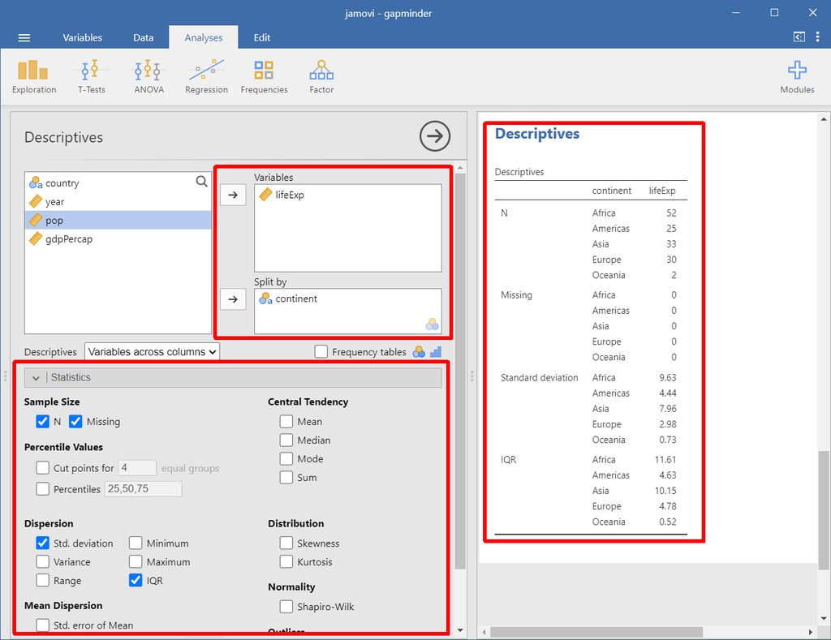

`lifeExp` split by `continent`

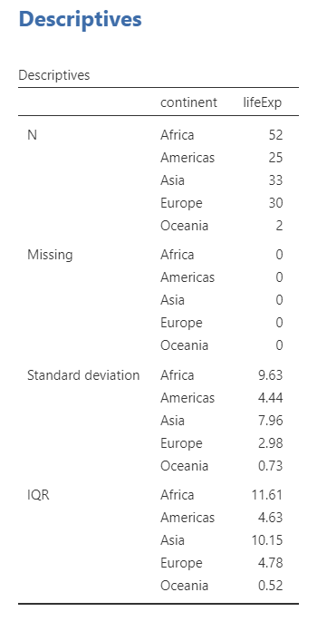

Descriptive statistics for `lifeExp` split by `continent`

5. Save and send the file `gapminder.omv` to the `abari.kurzus@gmail.com`. The subject of this email is `Lab08 - Problem 4`.

**Spread measures**

Spread measures in statistics are used to describe the extent to which data points in a dataset vary or are dispersed from the central tendency measures (mean, median, mode). Spread measures provide insights into the distribution of the data, how widely it is distributed, and the degree of variability within the dataset. There are several common spread measures, and here are a few of the most important ones:

- **Range**
  - The range is the simplest spread measure and is calculated as the difference between the maximum and minimum values in a dataset.
  - Formula: Range = Maximum Value - Minimum Value.
  - While the range is easy to compute, it can be sensitive to outliers and might not provide a robust measure of spread, especially when dealing with skewed or irregular distributions.
- **Interquartile Range (IQR)**
  - The IQR is a more robust measure of spread that is based on quartiles. Quartiles divide the data into four equal parts, and the IQR is the range of the middle 50% of the data.
  - Formula: IQR = Q3 (third quartile) - Q1 (first quartile).
  - The IQR is less affected by extreme values and is particularly useful for skewed datasets.
- **Variance and Standard Deviation**
  - Variance measures the average squared deviation of data points from the mean. **Standard deviation is the square root of variance and is expressed in the same units as the original data.**
  - Formulas: Variance (s²) = Σ((x - $\bar{x}$)²) / (n - 1), Standard Deviation (s) = √Variance.
  - Variance and standard deviation provide a more detailed assessment of the spread and are sensitive to the magnitude of deviations from the mean.

The choice of which spread measure to use depends on the nature of the data, the research question, and the presence of outliers. Each spread measure provides different information about the data’s variability, and the appropriate measure to use may vary from one situation to another.

Like mean and standard deviation, median and IQR measure the central tendency and spread, respectively, but are robust to outliers and non-normal data.

## Problem 5

> In this section, you will learn how to apply your knowledge of descriptive statistics to categorical and numerical variables.

You will use data from **birthwt** dataset. The data were collected at Baystate Medical Center, Springfield, Mass during 1986. It can be downloaded from this [link](https://vincentarelbundock.github.io/Rdatasets/csv/MASS/birthwt.csv). You can find the codebook [here](https://vincentarelbundock.github.io/Rdatasets/doc/MASS/birthwt.html).

1. Formulate 4 questions about the birthwt database. Answer them according to Problem 1-4 in this Lab.
2. The questions and the text answers, as well as the screenshots of the jamovi, are summarised in a `birthwt.html` file.
3. Send your `birthwt.html` and `birthwt.omv` to the `abari.kurzus@gmail.com`. The subject of this email is `Lab08 - Problem 5`.